# Coursera Data Science Specialization capstone project - Week 2

Celine B.

1/8/2022

## Introduction

The aim of the Coursera Data Science Specialization capstone project is to develop a predictive model of text using a very large and unstructured database of the English language. This report is the first assignment of the project: it shows the exploratory analyses performed on the data.

Code used is available in Appendix at the end of the report

## Exploratory analyses

### Summary statistics

```r
#Print data.frame of summary statistics
print(dfstats)
```

```
##      File     Size   Lines Characters WhiteSpaces    Words
## 1 Twitter   319 Mb 2360148  125570778    35958529 30451170
## 2    Blog 255.4 Mb  899288  162464653    42636700 37570839
## 3    News 257.3 Mb 1010242  162227130    40263955 34494539
```

We can observe that the 3 datasets are indeed very large. Due to the huge amount of data and the limited computational resources, datasets will be down-sampled for the exploratory analyses. The steps performed are (1) data sampling, (2) data cleaning and (2) tokenization using n-grams.

### Data sampling

Due to the size of the data and the limited computational resources, dataset are down-sampled and 10k sentences are kept for each of them. In addition, the 3 datasets are combined into one to perform exploratory analyses and observe the difference in words and n-grams frequency between individual datasets and all merged.

### Data cleaning

This step consist into cleaning the data and transform it into a corpus object for analyses. The cleaning step will remove non-English characters, text within brackets, twitter handle, emails, URLs, punctuation, numbers, extra white spaces, stop words *(commonly used english words)* and profantiy words In addition, it replaces abbreviations and contractions by their original words *(qdap R package)*. All words are converted to lower case.

### Words frequency

This part of the report display the most frequent words for Twitter, Blogs, News and combined data.

#### Twitter

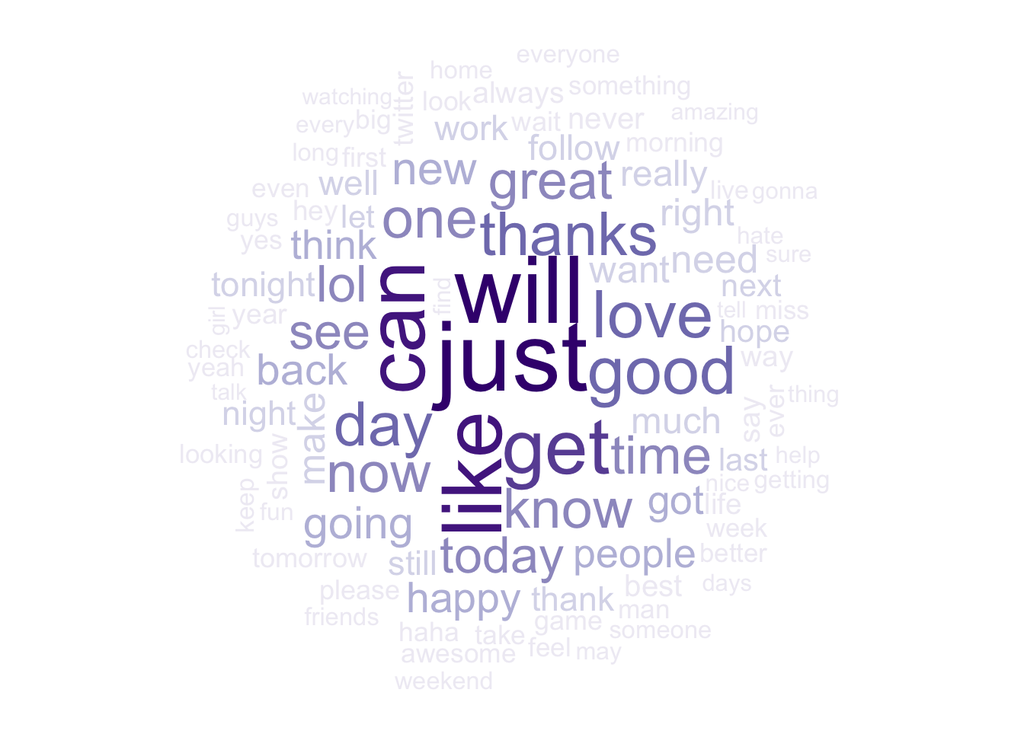

```r
wf_twits <- getWordCloud(twitCorpus)
wordcloud(words = wf_twits$Word,freq = wf_twits$Freq,min.freq = 1,max.words = 100,random.order = FALSE,colors=brewer.pal(9, "Purples"))
```

```r
rm(wf_twits)
```

#### Blogs

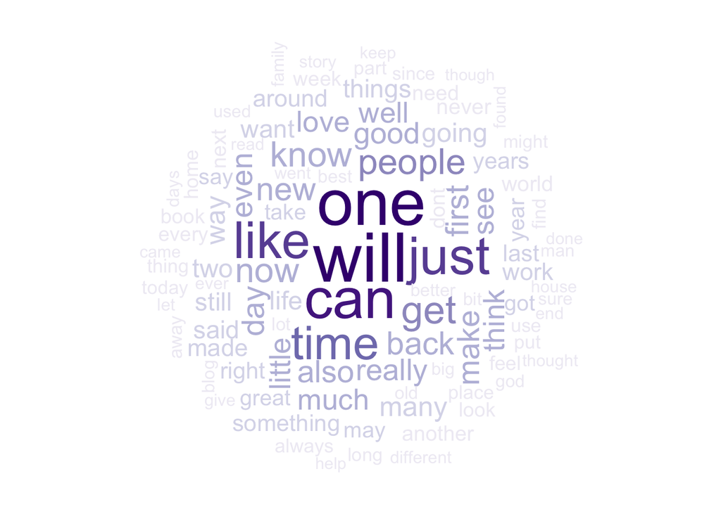

```r
wf_blogs <- getWordCloud(blogsCorpus)
wordcloud(words = wf_blogs$Word,freq = wf_blogs$Freq,min.freq = 1,max.words = 100,random.order = FALSE,colors=brewer.pal(9, "Purples"))
```

```r
rm(wf_blogs)
```

#### News

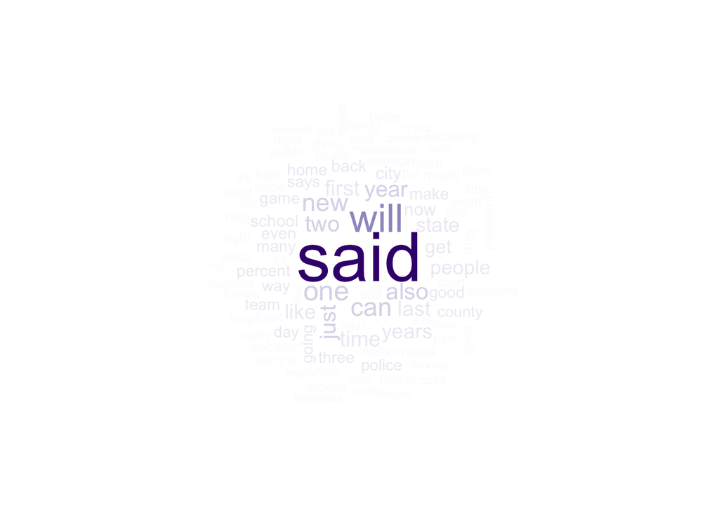

```r
wf_news <- getWordCloud(newsCorpus)
wordcloud(words = wf_news$Word,freq = wf_news$Freq,min.freq = 1,max.words = 100,random.order = FALSE,colors=brewer.pal(9, "Purples"))
```

```r
rm(wf_news)
```

#### All data

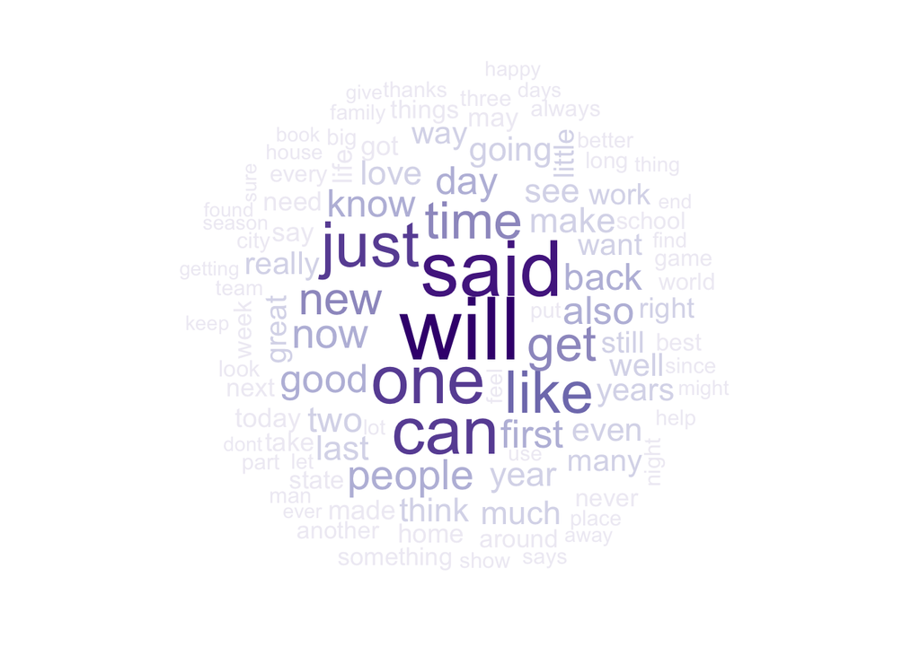

```r
wf_all <- getWordCloud(allCorpus)
wordcloud(words = wf_all$Word,freq = wf_all$Freq,min.freq = 1,max.words = 100,random.order = FALSE,colors=brewer.pal(9, "Purples"))
```

```r
rm(wf_all)
```

### n-Gram frequencies

This final part of the report show frequencies of N-grams with N = 2 or 3 for Twitter, Blogs, News and combined data. *Of note, 1-gram frequencies corresponds to the word clouds displayed in the previous part.*

#### Twitter

##### 2-grams

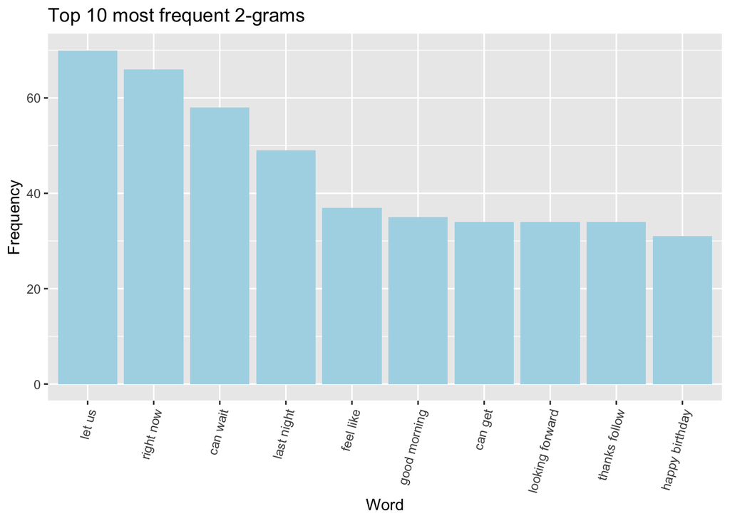

```r
print(getBarplotFreq(twitCorpus,2,"Top 10 most frequent 2-grams"))
```

##### 3-grams

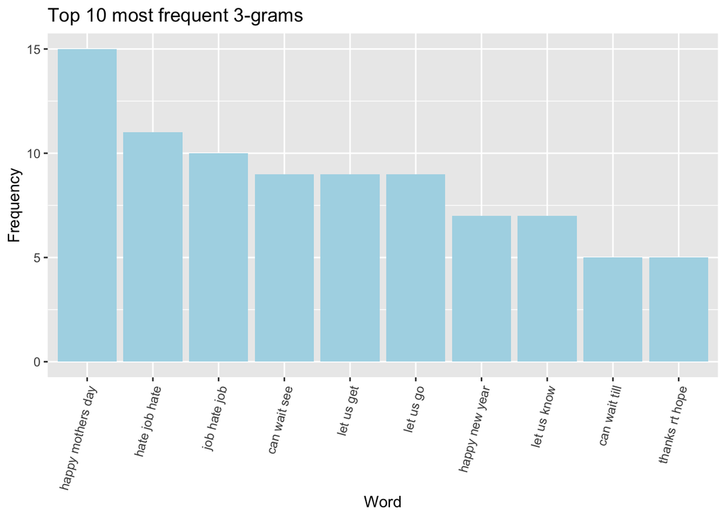

```r
print(getBarplotFreq(twitCorpus,3,"Top 10 most frequent 3-grams"))
```

```r
#Clean for memory
rm(twitCorpus)
```

#### Blogs

##### 2-grams

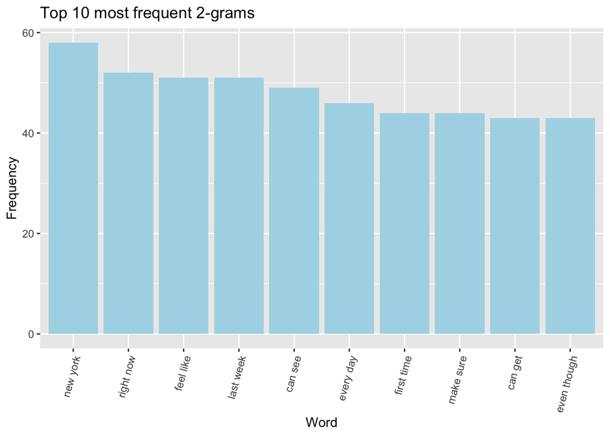

```r
print(getBarplotFreq(blogsCorpus,2,"Top 10 most frequent 2-grams"))
```

##### 3-grams

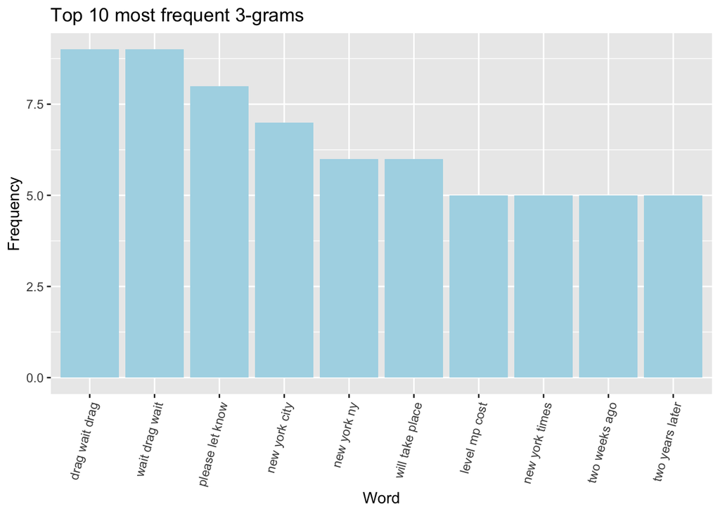

```r
print(getBarplotFreq(blogsCorpus,3,"Top 10 most frequent 3-grams"))
```

```r
#Clean for memory
rm(blogsCorpus)
```

#### News

##### 2-grams

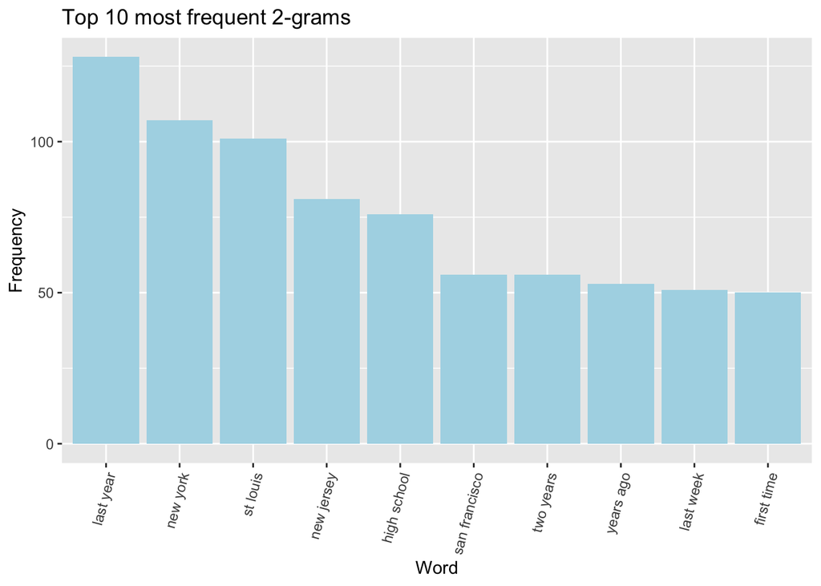

```r
print(getBarplotFreq(newsCorpus,2,"Top 10 most frequent 2-grams"))
```

##### 3-grams

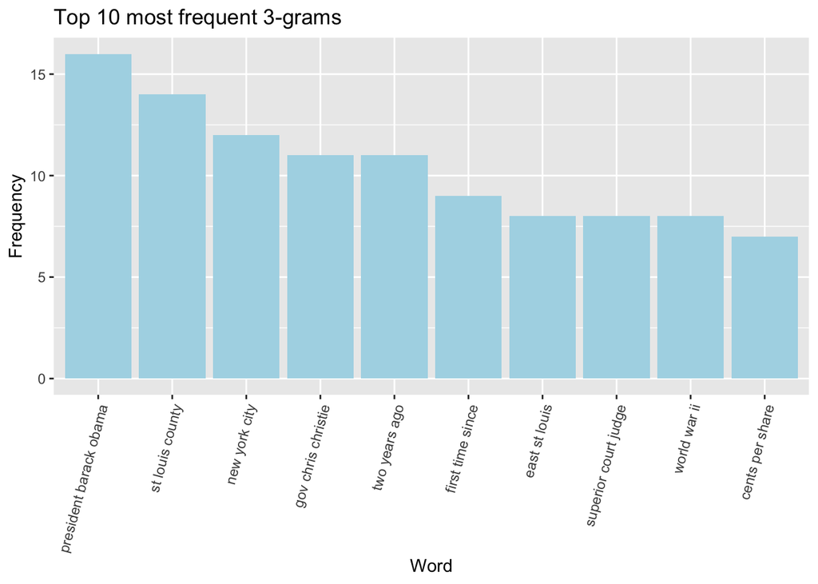

```r
print(getBarplotFreq(newsCorpus,3,"Top 10 most frequent 3-grams"))
```

```r
#Clean for memory
rm(newsCorpus)
```

#### All data

##### 2-grams

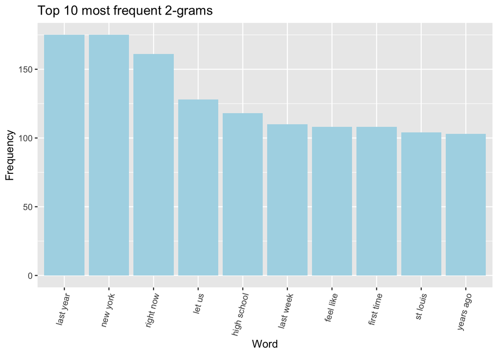

```r
print(getBarplotFreq(allCorpus,2,"Top 10 most frequent 2-grams"))
```

##### 3-grams

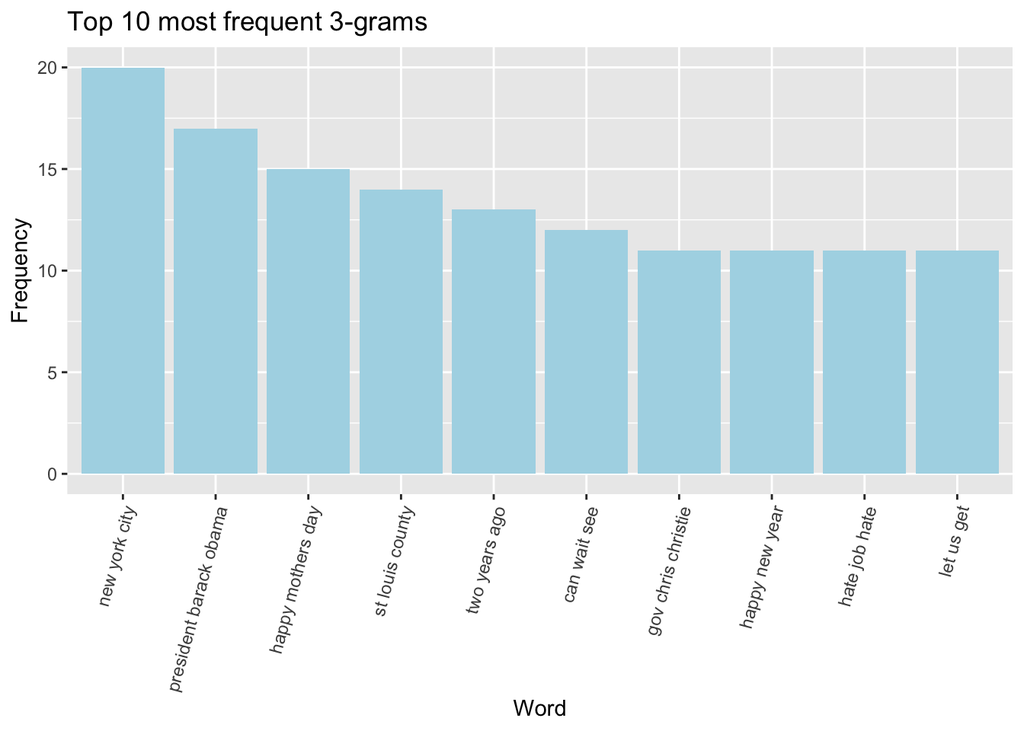

```r
print(getBarplotFreq(allCorpus,3,"Top 10 most frequent 3-grams"))
```

```r
#Clean for memory
rm(allCorpus)
```

### Summary

This exploratory analysis allowed us to **get a sense of the words distribution and their relationship**. For the predictive model, the combination of the 3 datasets will be used and, due to their large size a solution will be implemented to systematically retrieve word frequencies by subsets that will be merged into a final database. This will be used to generate N-grams dictionaries that will be of stored and used to build the predictive model.

## Appendix

### Libraries

```r
#Load libraries used
library(tm)
library(RWeka)
library(R.utils)
library(stringr)
library(stringi)
library(wordcloud)
library(RColorBrewer)
library(ggplot2)
library(qdap)
library(Matrix)
```

### Summary statistics

```r
#Load the data
conTwits <- file(paste0(pathData,"en_US.twitter.txt"), "r")
twits <- readLines(conTwits,skipNul = TRUE)
close(conTwits)
conBlogs <- file(paste0(pathData,"en_US.blogs.txt"), "r")
blogs <- readLines(conBlogs,skipNul = TRUE)
close(conBlogs)
conNews <- file(paste0(pathData,"en_US.news.txt"), "r")
news <- readLines(conNews,skipNul = TRUE)
close(conNews)

#Basic stats using stringi
stats_twits <- stri_stats_latex(twits)
stats_blogs <- stri_stats_latex(blogs)
stats_news <- stri_stats_latex(news)

#Data.frame of summary statistics
dfstats <- data.frame("File"=c("Twitter","Blog","News"),
                      "Size"=c(format(object.size(twits),"MB"),format(object.size(blogs),"MB"),format(object.size(news),"MB")),
                      "Lines"=c(as.numeric(countLines(paste0(pathData,"en_US.twitter.txt"))),
                                as.numeric(countLines(paste0(pathData,"en_US.blogs.txt"))),
                                as.numeric(countLines(paste0(pathData,"en_US.news.txt")))),
                      "Characters"=c(as.numeric(stats_twits[1]),as.numeric(stats_blogs[1]),as.numeric(stats_news[1])),
                      "WhiteSpaces"=c(as.numeric(stats_twits[3]),as.numeric(stats_blogs[3]),as.numeric(stats_news[3])),
                      "Words"=c(as.numeric(stats_twits[4]),as.numeric(stats_blogs[4]),as.numeric(stats_news[4]))
                      )
```

### Data sampling

```r
#Set seed for reproducibility
set.seed(1234)

#Down-sample Twitter
subtwits <- sample(twits,10000,replace=F)

#Down-sample Blogs
subblogs <- sample(blogs,10000,replace=F)

#Down-sample News
subnews <- sample(news,10000,replace=F)

#Combine all
suball <- c(subtwits,subblogs,subnews)

#Free space
rm(twits)
rm(blogs)
rm(news)
gc()
```

### Data cleaning

```r
#Function to create clean corpus:
# (2) clean data: remove twitter handle, emails, URLs, punctuation, numbers, extra white spaces, stop words & transform all words to lower case
# (3) remove profanity
getCleanCorpus <- function(docsText,profanityWords){

  #Remove non-English characters
  docsText <- iconv(docsText,"latin1","ASCII",sub="")

  #Remove specific words found highly frequent: www, dot, com
  docsText <- str_replace_all(docsText,"www","")
  docsText <- str_replace_all(docsText,"dot","")
  docsText <- str_replace_all(docsText,"com","")

  #Remove repetition of words
  docsText <- str_replace_all(docsText,"(\\w+[:space:])\\1+","\\1")

  #Remove text within brackets
  docsText <- bracketX(docsText)

  #Replace abbreviations
  docsText <- replace_abbreviation(docsText)

  #Replace contractions
  docsText <- replace_contraction(docsText)

  #Remove repetition of words
  docsText <- sapply(docsText,function(w){paste(unique(w),collapse = " ")},simplify = TRUE)

  #Create corpus object
  corpusObj <- VCorpus(VectorSource(docsText))

  #Regex function
  cleanUsingRegex <- content_transformer(function(w,regexExp) gsub(regexExp," ",w))

  #Remove Twitter #
  corpusObj <- tm_map(corpusObj,cleanUsingRegex,"@[^\\s]{1,15}")

  #Remove emails
  corpusObj <- tm_map(corpusObj,cleanUsingRegex,"^[[:alnum:].-_]+@[[:alnum:].-]+$")

  #Remove URLs
  corpusObj <- tm_map(corpusObj,cleanUsingRegex,"(f|ht)tp[s]?://(?:[a-zA-Z]|[0-9]|[$-_@.&+]|[!*\\(\\),]|(?:%[0-9a-fA-F][0-9a-fA-F]))+")

  #Remove punctuation
  corpusObj <- tm_map(corpusObj,removePunctuation)

  #Remove numbers
  corpusObj <- tm_map(corpusObj,removeNumbers)

  #Remove extra white spaces
  corpusObj <- tm_map(corpusObj,stripWhitespace)

  #Transform into lower case
  corpusObj <- tm_map(corpusObj,content_transformer(tolower))

  #Remove stop words
  corpusObj <- tm_map(corpusObj, removeWords, stopwords("english"))

  #Remove profanity words
  corpusObj <- tm_map(corpusObj, removeWords, profanityWords)

  corpusObj <- tm_map(corpusObj, PlainTextDocument)

  #Return
  return(corpusObj)
}
```

```r
#Load profanity words
#Downloaded from https://raw.githubusercontent.com/shutterstock/List-of-Dirty-Naughty-Obscene-and-Otherwise-Bad-Words/master/en
conBadWords <- file(paste0(pathBadWords,"profanityWords.txt"), "r")
profanityWords <- VectorSource(readLines(conBadWords))
close(conBadWords)

#Clean Twitter corpus
twitCorpus <- getCleanCorpus(subtwits,profanityWords)
rm(subtwits)

#Clean Blogs corpus
blogsCorpus <- getCleanCorpus(subblogs,profanityWords)
rm(subblogs)

#Clean News corpus
newsCorpus <- getCleanCorpus(subnews,profanityWords)
rm(subnews)

#Clean All corpus
allCorpus <- getCleanCorpus(suball,profanityWords)
rm(suball)
```

### Words frequency

```r
#Function to get word frequency
getWordCloud <- function(corpusObj){
  mtx <- as.matrix(TermDocumentMatrix(corpusObj))
  mtxfreq <- sort(rowSums(mtx), decreasing = TRUE)
  wfreq <- data.frame("Word" = names(mtxfreq), "Freq" = mtxfreq)
  return(wfreq)
}
```

### n-Gram frequencies

```r
#Function to tokenize into n-gram
N2gramToken <- function(w){NGramTokenizer(w,Weka_control(min=2,max=2))}
N3gramToken <- function(w){NGramTokenizer(w,Weka_control(min=3,max=3))}

#Function to plot barplot of top 10 most frequent n-gram
getBarplotFreq <- function(corpusText,ngram,ttl){

  # Term document obj depending on N-gram
  if(ngram==2){
    tdm <- TermDocumentMatrix(corpusText, control = list(tokenize = N2gramToken))
  }else{
    tdm <- TermDocumentMatrix(corpusText, control = list(tokenize = N3gramToken))
  }

  #Convert to sparseMatrix
  mtx <-  Matrix::sparseMatrix(i=tdm$i,j=tdm$j,x=tdm$v,dims=c(tdm$nrow, tdm$ncol),dimnames = tdm$dimnames)
  rm(tdm)

  # Frequency
  freq <- sort(Matrix::rowSums(mtx), decreasing = TRUE)
  # Freq fataframe
  freqdf <- data.frame("Word" = names(freq), "Freq" = freq)

  # Plot
  top10 <- freqdf[1:10,]
  p <- ggplot(top10,aes(x=reorder(Word,-Freq),y=Freq)) +
    geom_bar(stat="identity", fill="lightblue") +
    theme(axis.text.x = element_text(angle = 75,vjust=1,hjust=1)) +
    xlab("Word") +
    ylab("Frequency") +
    ggtitle(ttl)

  #Clean
  rm(mtx)
  rm(freq)
  rm(freqdf)
  rm(top10)
  gc()

  #Return
  return(p)
}
```